# TeoNAM STAM — OLS GWAS on the authentic 118K GWAS panel (Fig 4C)

Per-marker across-family OLS on Chen 2019’s 118,838-SNP GWAS panel (v5) — computation, model & QC

Author

Fausto Rodríguez-Zapata

Published

July 10, 2026

**What this is.** The *computation* behind the STAM OLS GWAS scan on the **authentic 118,838-SNP Chen 2019 GWAS panel** (Qiuyue Chen’s Drive release), lifted to B73 v5 (`data/teonam/stam_gwas_scan_118k.csv`), tracked in its own right. It ports the `scripts/teonam_stam_gwas118k.R` scan into a rendered notebook so the scan — not just its Manhattan — is reproducible from primary data. The annotated Fig-4C Manhattan that *consumes* this CSV lives in `teonam-qtl-recovery`; this notebook **produces** it.

This is the **faithful** Fig 4C marker set: Chen’s GWAS SNPs (GBS filtered at MAF > 0.01, missing rate < 0.75, then FSFHap-imputed per subpopulation, combined, and re-filtered to MAF > 0.05 / missing < 0.2 → 118,838 SNPs), lifted v2 → v5 (118,514 lifted). It **replaces the 51K map-panel approximation** used by `teonam-stam-ols-gwas-family-imputed`; the model is **identical** (`STAM ~ Family + marker`, 1-df F), so the two are directly comparable — only the marker set differs (118K GWAS panel vs 51K map panel). As there, each marker is tested only on the families that typed it (cross-family gaps left as NA, **not** densified), giving natural GWAS scatter.

```r
library(here)
library(data.table)
library(parallel)
library(readxl)
library(ggplot2)
theme_set(theme_bw(base_size = 12))
THREADS <- max(1L, detectCores() - 2L)
LOD <- 5 # Chen 2019 significance line: P < 1e-5
```

## Inputs (primary 118K dosage + phenotype + v5 liftover)

```r
# 118K GWAS-panel dosage: integer matrix [markers x lines], NA = untyped (0/1/2)
g118 <- readRDS(here("data/teonam/teonam_gwas118k_dosage.rds"))
dos <- g118$dos
lines <- colnames(dos)
fam <- factor(substr(lines, 1, 5)) # TIL01A001 -> TIL01

# phenotype: STAM (staminate spikelet), joined by line key
ph <- as.data.frame(read_excel(
  here("data/teonam/9250682/TeoNAM_1257RILs_22traits_phenotype_data.xlsx")
))
names(ph)[1] <- "line"
y <- suppressWarnings(as.numeric(setNames(ph$STAM, ph$line)[lines]))

# v5 coordinates; restrict the scan to 118K markers that lifted to v5
mc <- fread(here("data/teonam/markers_v5_gwas118k.tsv"))
chr_by <- setNames(mc$chr_v5, mc$marker)
pos_by <- setNames(mc$pos_v5, mc$marker)
mk <- intersect(rownames(dos), mc$marker)
mk_idx <- match(mk, rownames(dos))

data.table(
  quantity = c(
    "lines", "markers (panel)", "markers (lifted, scanned)",
    "STAM phenotyped", "families"
  ),
  value = c(
    length(lines), nrow(dos), length(mk),
    sum(!is.na(y)), nlevels(fam)
  )
)
```

```
                    quantity  value
                      <char>  <int>
1:                     lines   1257
2:           markers (panel) 118838
3: markers (lifted, scanned) 118514
4:           STAM phenotyped   1256
5:                  families      5
```

## The model

Identical to the family-imputed 51K notebook. For each marker $m$, restrict to the lines $i$ with a non-missing dosage $g_{im}\in\{0,1,2\}$ **and** a non-missing STAM value $y_i$, then compare two nested least-squares fits:

$$\textbf{Null:}\quad y_i = \mu + \sum_{f} \beta_f \,\mathbb{1}[\text{family}_i = f] + \varepsilon_i$$
$$\textbf{Full:}\quad y_i = \mu + \sum_{f} \beta_f \,\mathbb{1}[\text{family}_i = f] + \gamma\, g_{im} + \varepsilon_i$$

The marker enters as a **single additive dosage effect $\gamma$ shared across families** (1 numerator df). Significance is the marginal $F$-test of $\gamma$:

$$F = \frac{(\mathrm{RSS}_0 - \mathrm{RSS}_1)/1}{\mathrm{RSS}_1/(n - \mathrm{rank})},
\qquad P = \Pr\big(F_{1,\,n-\mathrm{rank}} > F\big).$$

Family is a fixed categorical covariate (levels dropped to those present for that marker). **This is OLS: no kinship/polygenic random effect $K$** — deliberately the same fixed-effects model as the 51K notebook, *not* Chen’s `Q(5 PCs) + SNP + K(IBS)` mixed model, so peak heights run hotter (the $\lambda_{GC}$/QQ comparison is a separate analysis).

## The scan

```r
scan1 <- function(i) {
  g <- dos[i, ] # dosage across lines, NA where untyped
  ok <- !is.na(g) & !is.na(y)
  n <- sum(ok)
  if (n < 20) {
    return(c(NA_real_, n))
  }
  gg <- as.numeric(g[ok])
  if (stats::sd(gg) == 0) {
    return(c(NA_real_, n))
  }
  yy <- y[ok]
  ff <- droplevels(fam[ok])
  Xr <- if (nlevels(ff) > 1) model.matrix(~ff) else matrix(1, n, 1)
  RSS0 <- sum(lm.fit(Xr, yy)$residuals^2)
  fit <- lm.fit(cbind(Xr, gg), yy)
  RSS1 <- sum(fit$residuals^2)
  df2 <- n - fit$rank
  if (df2 <= 0 || RSS1 <= 0) {
    return(c(NA_real_, n))
  }
  c(pf(((RSS0 - RSS1) / 1) / (RSS1 / df2), 1, df2, lower.tail = FALSE), n)
}
out <- mclapply(mk_idx, scan1, mc.cores = THREADS)
P <- vapply(out, `[`, numeric(1), 1)
N <- vapply(out, `[`, numeric(1), 2)

scan <- data.table(
  SNP = mk, CHR = as.integer(chr_by[mk]),
  BP = as.integer(pos_by[mk]), P = P,
  n = as.integer(N)
)[order(CHR, BP)]
fwrite(scan, here("data/teonam/stam_gwas_scan_118k.csv")) # canonical output
```

## QC and results

```r
fin <- scan[is.finite(P) & P > 0]
data.table(
  metric = c(
    "markers scanned", "markers tested (finite P)",
    "median lines / marker", "max -log10P",
    sprintf("genome-wide sig. (P < 1e-%d)", LOD)
  ),
  value = c(
    nrow(scan), nrow(fin), median(scan$n),
    round(max(-log10(fin$P)), 2), sum(fin$P < 10^(-LOD))
  )
)
```

```
                        metric     value
                        <char>     <num>
1:             markers scanned 118514.00
2:   markers tested (finite P) 118514.00
3:       median lines / marker   1254.00
4:                 max -log10P     19.84
5: genome-wide sig. (P < 1e-5)  12040.00
```

```r
top <- fin[order(P)][1:10, .(SNP, CHR, BP, n, logP = round(-log10(P), 2))]
knitr::kable(top, caption = "Top 10 STAM associations (118K GWAS panel)")
```

Top 10 STAM associations (118K GWAS panel)

| SNP | CHR | BP | n | logP |
| --- | --- | --- | --- | --- |
| S1_265481570 | 1 | 272066747 | 1256 | 19.84 |
| S1_272351287 | 1 | 278901185 | 1158 | 19.62 |
| S1_264498237 | 1 | 271086172 | 1256 | 19.61 |
| S1_266044177 | 1 | 272634195 | 1190 | 19.21 |
| S1_275224100 | 1 | 281860483 | 1189 | 18.99 |
| S1_267160582 | 1 | 273734045 | 1224 | 18.92 |
| S1_266098452 | 1 | 272698702 | 1248 | 18.91 |
| S1_263652153 | 1 | 270280166 | 1254 | 18.90 |
| S1_273101092 | 1 | 279660732 | 1153 | 18.87 |
| S1_270669124 | 1 | 277196538 | 1256 | 18.76 |

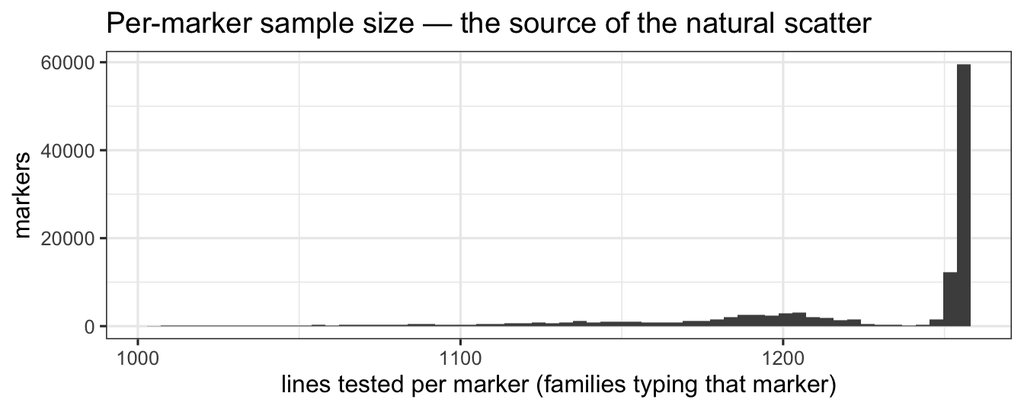

```r
ggplot(scan, aes(n)) +
  geom_histogram(bins = 60, fill = "grey30") +
  labs(
    x = "lines tested per marker (families typing that marker)",
    y = "markers", title = "Per-marker sample size — the source of the natural scatter"
  )
```

[figure not shown]

```r
# lightweight Manhattan (the annotated Fig-4C version lives in teonam-qtl-recovery)
m <- fin[order(CHR, BP)]
off <- m[, .(mx = max(BP)), by = CHR][order(CHR)]
off[, base := cumsum(shift(mx, fill = 0))]
m <- merge(m, off[, .(CHR, base)], by = "CHR")
m[, x := BP + base]
axis <- m[, .(mid = (min(x) + max(x)) / 2), by = CHR][order(CHR)]
ggplot(m, aes(x, -log10(P), colour = factor(CHR %% 2))) +
  geom_point(size = 0.4) +
  geom_hline(yintercept = LOD, linetype = "dotted") +
  scale_colour_manual(values = c("grey60", "black"), guide = "none") +
  scale_x_continuous(breaks = axis$mid, labels = axis$CHR, expand = c(0.01, 0)) +
  labs(
    x = "chromosome", y = expression(-log[10](italic(P))),
    title = "STAM 118K GWAS (OLS: STAM ~ Family + marker)"
  )
```

## Notes

- This notebook is the **canonical, tracked source** for `stam_gwas_scan_118k.csv`; it ports `scripts/teonam_stam_gwas118k.R` verbatim (same OLS model as the 51K family-imputed notebook).
- The marker set is the **authentic Chen 2019 GWAS panel** (118,838 SNPs → 118,514 lifted to v5), *not* the 51K map panel. Same model, different markers → the two OLS notebooks are directly comparable.
- Model is **OLS (fixed effects), no kinship term** — the peak-height / $\lambda_{GC}$ comparison against Chen’s `Q + K` mixed model is deferred to a dedicated inflation notebook (the 118K MLM analog is not yet built).